# COVID-19 in Three Counties - Final Project

Wyatt Waterbury

January 07, 2022

## Introduction

COVID-19 continues to sweep the globe and with every new variant of the coronavirus comes another surge of cases. This report will focus on three (3) counties in Michigan; *Ionia*, *Kalamazoo*, and *Mecosta*. Taking a look at the total cases over time across these three counties will provide insight at how impacted they were from COVID-19 and when each variant has been introduced in their population.

## Data

The Michigan COVID-19 data for this document were obtained at https://www.michigan.gov/coronavirus/0,9753,7-406-98163_98173---,00.html in the Public Use Datasets called “Cases by County and Date”. The **December 29, 2021** dataset was used to create this report. Michigan county populations were found at https://worldpopulationreview.com/us-counties/states/mi which gives the 2018 census numbers. These were the most recent reliable numbers that I could find at the moment.

## Data munging

The Michigan COVID-19 dataset had a few peculiarities that needed to be dealt with in order to analyze it easily. There were several “counties” that are not actual Michigan counties that needed to be cleaned. The values for “Out-of-State” are not relevant for my purposes and were removed from the analyses. Likewise, prison populations (“FCI” and “MDOC”) cannot be ascribed to particular counties and were, therefore, also removed. Cases with “Unknown” origins were also removed. Finally, the dataset lists “City of Detroit” as a separate entity, those numbers were added back into it’s home country (Wayne) to facilitate analysis.

The number of cases and deaths per day are recorded for both confirmed and probable cases. To be as conservative as possible, these numbers were added together to create a total number of cases and deaths per day from each county (along with total cumulative cases and deaths). These total values, confirmed + probable, are used for all of the analyses in this report.

GIS information was left-joined onto the total data. The census data was also left-joined and used to create population-normalized values (cases or deaths per 100,000 population).

## Statewide distribution

Below shows the cumulative distribution of cases and mortalities in all counties throughout Michigan. Shown in the first map distribution (A), Wayne County has the most cases and the surrounding counties, as well as Kent County, also experience high numbers. In the second map distribution (B), similarly to the number of cases, Wayne County leads in mortalities and the surrounding counties, as well as Kent County, follow behind.

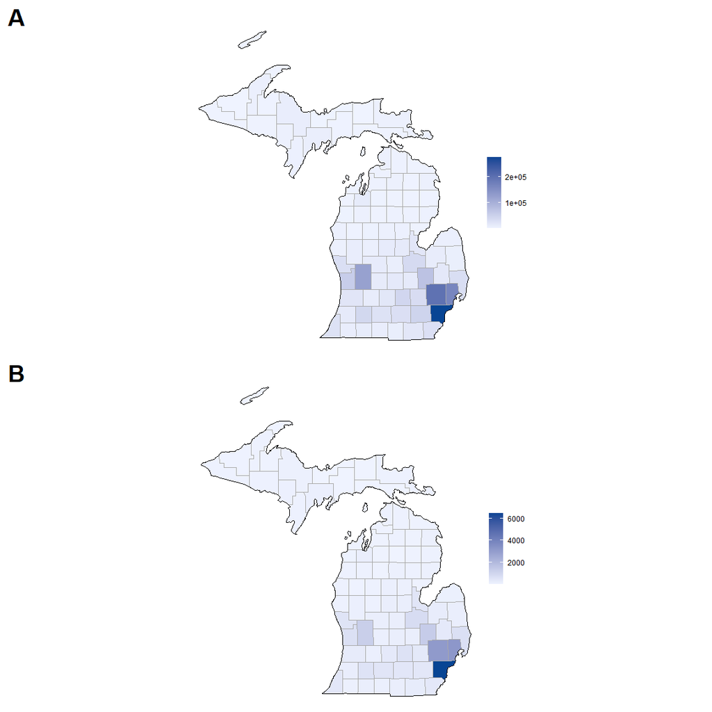

**Figure 1:** The map shows all the Michigan counties with a certain level of blue indicating the amount of cases/deaths from that county. The darker the blue indicates the higher the totals for cases or deaths. In (A), the darkest blue seen in Wayne County symbolizes around 300,000 cumulative cases of COVID-19. In (B), the darkest blue indicates around 6200 cumulative deaths from COVID-19.